# TipologiaDades-Practica2

Silvia Benet, Marc Garrido

07/06/2020

# 1. Descripció del Dataset.

Hem decidit utilitzar el dataset red-wine-quality:

https://www.kaggle.com/uciml/red-wine-quality-cortez-et-al-2009

“P. Cortez, A. Cerdeira, F. Almeida, T. Matos and J. Reis. Modeling wine preferences by data mining from physicochemical properties. In Decision Support Systems, Elsevier, 47(4):547-553, 2009.”

L’hem triat perquè considerem que ens permetrà provar diferents metodologies ja que té una quantitat prou important de variables d’entrada i a més conté una variable de sortida que ens permetrà entrenar i testejar els algoritmes.

El que pretenem respondre és a la pregunta de quina variable té més pes en la qualitat del vi i segons uns valors donats de les variables d’entrada volem saber de quina qualitat serà el vi resultant. Per tant aplicarem diferents algoritmes que ens facin una predicció de la variable qualitat.

```r
library(ggplot2)
library(dplyr)
library(corrplot)
wineQualityRed <- read.csv('winequality-red.csv', stringsAsFactors = FALSE, header = TRUE, sep=";")

names(wineQualityRed) <- c("fixedacidity",
   "volatileacidity",
   "citricacid",
   "residualsugar",
   "chlorides",
   "freesulfurdioxide",
   "totalsulfurdioxide",
   "density",
   "pH",
   "sulphates",
   "alcohol",
   "quality")


head(wineQualityRed)
```

```
##   fixedacidity volatileacidity citricacid residualsugar chlorides
## 1          7.4            0.70       0.00           1.9     0.076
## 2          7.8            0.88       0.00           2.6     0.098
## 3          7.8            0.76       0.04           2.3     0.092
## 4         11.2            0.28       0.56           1.9     0.075
## 5          7.4            0.70       0.00           1.9     0.076
## 6          7.4            0.66       0.00           1.8     0.075
##   freesulfurdioxide totalsulfurdioxide density   pH sulphates alcohol quality
## 1                11                 34  0.9978 3.51      0.56     9.4       5
## 2                25                 67  0.9968 3.20      0.68     9.8       5
## 3                15                 54  0.9970 3.26      0.65     9.8       5
## 4                17                 60  0.9980 3.16      0.58     9.8       6
## 5                11                 34  0.9978 3.51      0.56     9.4       5
## 6                13                 40  0.9978 3.51      0.56     9.4       5
```

## Descripció de les variables.

1 - fixed acidity: Quantitat d’àcid del vi.

2 - volatile acidity: La quantitat d’àcid acètic que té el vi.

3 - citric acid: La quantitat d’àcid cítric que té el vi.

4 - residual sugar: La quantitat del sucre que resta després de la fermentació.

5 - chlorides: La quantitat de sal.

6 - free sulfur dioxide: La quantitat “lliure” de SO2.

7 - total sulfur dioxide: La quantitat total de SO2.

8 - density: La densitat del líquid

9 - pH: Grau d’acidessa.

10 - sulphates: La qantitat de sulfats que té el vi.

11 - alcohol: EL percentatge d’alcohol que conté el vi.

12 - quality: La variable output, la puntuació del vi.

# 2. Integració i selecció de les dades.

En aquest cas no veiem necessari eliminar cap atribut, hi ha uns de més importants d’altres, però amb 11 atributs no voldriem eliminar-ne cap.

## Tipus de les variables.

```r
library(knitr)
library(kableExtra)
res <- sapply(wineQualityRed,class)
kable(data.frame(variables=names(res),clase=as.vector(res)))
```

| variables | clase |
| --- | --- |
| fixedacidity | numeric |
| volatileacidity | numeric |
| citricacid | numeric |
| residualsugar | numeric |
| chlorides | numeric |
| freesulfurdioxide | numeric |
| totalsulfurdioxide | numeric |
| density | numeric |
| pH | numeric |
| sulphates | numeric |
| alcohol | numeric |
| quality | integer |

Veiem que totes les variables són de tipus numeric, excepte l’última que és classe integrer.

Deixarem l’últim atribut com a enter, ja que aquest és un número del zero al deu i és la classe output, la que es vol predir.

# 3. Neteja de les dades

Comprovem l’estructura del joc de dades

```r
str(wineQualityRed)
```

```
## 'data.frame':    1599 obs. of  12 variables:
##  $ fixedacidity      : num  7.4 7.8 7.8 11.2 7.4 7.4 7.9 7.3 7.8 7.5 ...
##  $ volatileacidity   : num  0.7 0.88 0.76 0.28 0.7 0.66 0.6 0.65 0.58 0.5 ...
##  $ citricacid        : num  0 0 0.04 0.56 0 0 0.06 0 0.02 0.36 ...
##  $ residualsugar     : num  1.9 2.6 2.3 1.9 1.9 1.8 1.6 1.2 2 6.1 ...
##  $ chlorides         : num  0.076 0.098 0.092 0.075 0.076 0.075 0.069 0.065 0.073 0.071 ...
##  $ freesulfurdioxide : num  11 25 15 17 11 13 15 15 9 17 ...
##  $ totalsulfurdioxide: num  34 67 54 60 34 40 59 21 18 102 ...
##  $ density           : num  0.998 0.997 0.997 0.998 0.998 ...
##  $ pH                : num  3.51 3.2 3.26 3.16 3.51 3.51 3.3 3.39 3.36 3.35 ...
##  $ sulphates         : num  0.56 0.68 0.65 0.58 0.56 0.56 0.46 0.47 0.57 0.8 ...
##  $ alcohol           : num  9.4 9.8 9.8 9.8 9.4 9.4 9.4 10 9.5 10.5 ...
##  $ quality           : int  5 5 5 6 5 5 5 7 7 5 ...
```

Mirem un resum per fer un cop d’ull quins valors tenim

```r
summary(wineQualityRed)
```

```
##   fixedacidity   volatileacidity    citricacid    residualsugar
##  Min.   : 4.60   Min.   :0.1200   Min.   :0.000   Min.   : 0.900
##  1st Qu.: 7.10   1st Qu.:0.3900   1st Qu.:0.090   1st Qu.: 1.900
##  Median : 7.90   Median :0.5200   Median :0.260   Median : 2.200
##  Mean   : 8.32   Mean   :0.5278   Mean   :0.271   Mean   : 2.539
##  3rd Qu.: 9.20   3rd Qu.:0.6400   3rd Qu.:0.420   3rd Qu.: 2.600
##  Max.   :15.90   Max.   :1.5800   Max.   :1.000   Max.   :15.500
##    chlorides       freesulfurdioxide totalsulfurdioxide    density
##  Min.   :0.01200   Min.   : 1.00     Min.   :  6.00     Min.   :0.9901
##  1st Qu.:0.07000   1st Qu.: 7.00     1st Qu.: 22.00     1st Qu.:0.9956
##  Median :0.07900   Median :14.00     Median : 38.00     Median :0.9968
##  Mean   :0.08747   Mean   :15.87     Mean   : 46.47     Mean   :0.9967
##  3rd Qu.:0.09000   3rd Qu.:21.00     3rd Qu.: 62.00     3rd Qu.:0.9978
##  Max.   :0.61100   Max.   :72.00     Max.   :289.00     Max.   :1.0037
##        pH          sulphates         alcohol         quality
##  Min.   :2.740   Min.   :0.3300   Min.   : 8.40   Min.   :3.000
##  1st Qu.:3.210   1st Qu.:0.5500   1st Qu.: 9.50   1st Qu.:5.000
##  Median :3.310   Median :0.6200   Median :10.20   Median :6.000
##  Mean   :3.311   Mean   :0.6581   Mean   :10.42   Mean   :5.636
##  3rd Qu.:3.400   3rd Qu.:0.7300   3rd Qu.:11.10   3rd Qu.:6.000
##  Max.   :4.010   Max.   :2.0000   Max.   :14.90   Max.   :8.000
```

Amb un summary podem veure més o menys com són les dades per fer-nos una primera idea.

## 3.1 Identificació de valors nuls.

Mirarem si hi ha zeros i nuls

```r
colSums(is.na(wineQualityRed))
```

```
##       fixedacidity    volatileacidity         citricacid      residualsugar
##                  0                  0                  0                  0
##          chlorides  freesulfurdioxide totalsulfurdioxide            density
##                  0                  0                  0                  0
##                 pH          sulphates            alcohol            quality
##                  0                  0                  0                  0
```

```r
colSums(wineQualityRed=="")
```

```
##       fixedacidity    volatileacidity         citricacid      residualsugar
##                  0                  0                  0                  0
##          chlorides  freesulfurdioxide totalsulfurdioxide            density
##                  0                  0                  0                  0
##                 pH          sulphates            alcohol            quality
##                  0                  0                  0                  0
```

## 3.2 Identificació de valors extrems (outliers).

Utilitzant boxplot comprovarem si les variables tenen valors extrems i si aquests valors poden ser considerats vàlids i per tant s’han de tenir en compte o si al contrari són valors invàlids i s’han de tractar o eliminar.

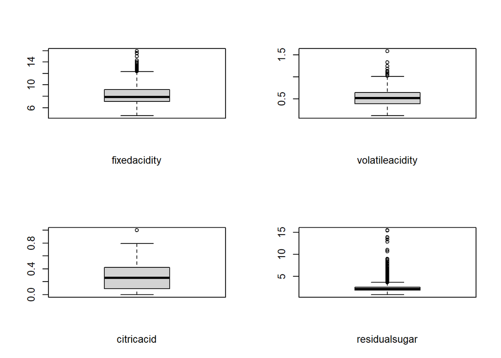

```r
par(mfrow=c(2,2))
boxplot(wineQualityRed$fixedacidity,xlab="fixedacidity")
boxplot(wineQualityRed$volatileacidity,xlab="volatileacidity")
boxplot(wineQualityRed$citricacid, xlab="citricacid")
boxplot(wineQualityRed$residualsugar,xlab="residualsugar")
```

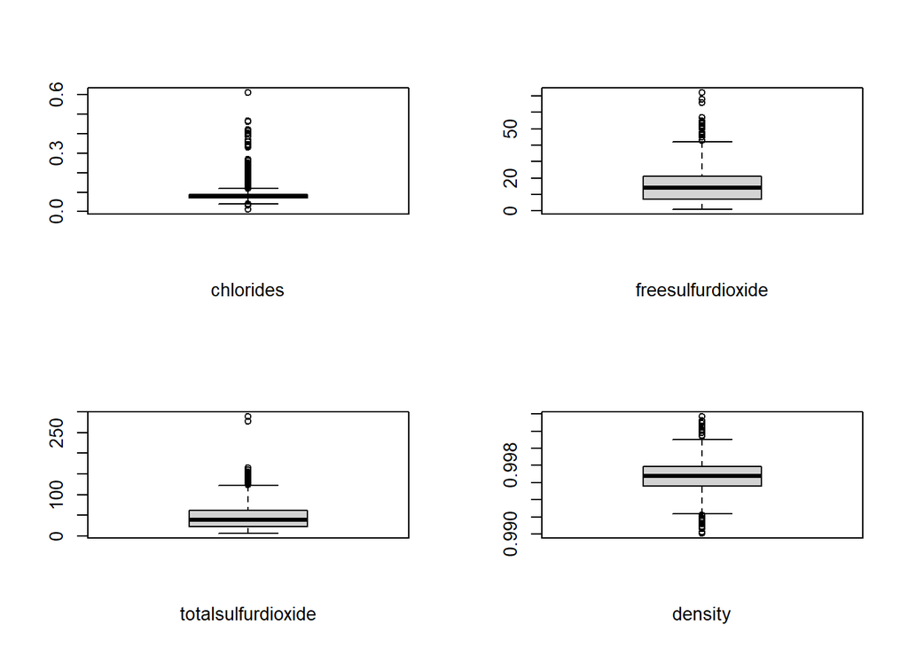

```r
boxplot(wineQualityRed$chlorides, xlab="chlorides")
boxplot(wineQualityRed$freesulfurdioxide, xlab ="freesulfurdioxide")
boxplot(wineQualityRed$totalsulfurdioxide,xlab ="totalsulfurdioxide" )
boxplot(wineQualityRed$density, xlab ="density")
```

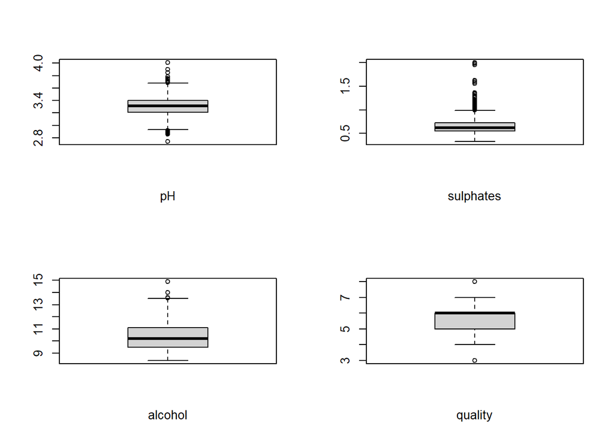

```r
boxplot(wineQualityRed$pH, xlab ="pH")
boxplot(wineQualityRed$sulphates, xlab ="sulphates")
boxplot(wineQualityRed$alcohol,xlab="alcohol")
boxplot(wineQualityRed$quality, xlab ="quality")
```

Citricacid té només un valor que està allunyat de la resta. Mirem quin és:

```r
boxplot(wineQualityRed$citricacid, plot =FALSE)$out
```

```
## [1] 1
```

Amb un summary podrem veure quins són els valors i quin és valor màxim per veure si realment està tan allunyat i és un valor no vàlid.

```r
summary(wineQualityRed$citricacid)
```

```
##    Min. 1st Qu.  Median    Mean 3rd Qu.    Max.
##   0.000   0.090   0.260   0.271   0.420   1.000
```

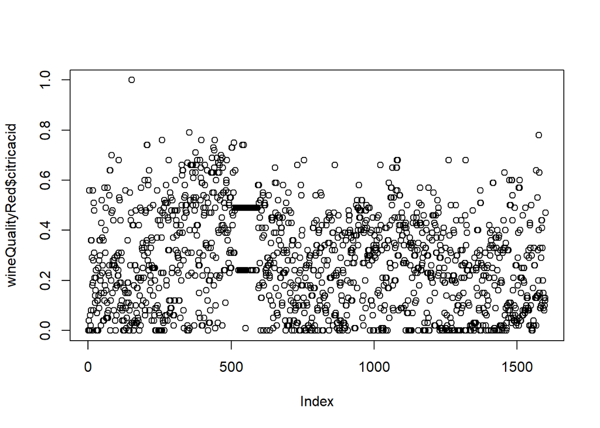

```r
plot(wineQualityRed$citricacid)
```

El valor que semblaria outiler és 1, el rang de la variable oscil.la entre 0 i 1, i hi ha valors de 0,8 així que no sembla pas un error. El deixarem tal com està.

Comprovarem totalsulfurdioxide perquè també sembla que tingui alguns valors allunyats:

```r
boxplot(wineQualityRed$totalsulfurdioxide, plot =FALSE)$out
```

```
##  [1] 145 148 136 125 140 136 133 153 134 141 129 128 129 128 143 144 127 126 145
## [20] 144 135 165 124 124 134 124 129 151 133 142 149 147 145 148 155 151 152 125
## [39] 127 139 143 144 130 278 289 135 160 141 141 133 147 147 131 131 131
```

```r
summary(wineQualityRed$totalsulfurdioxide)
```

```
##    Min. 1st Qu.  Median    Mean 3rd Qu.    Max.
##    6.00   22.00   38.00   46.47   62.00  289.00
```

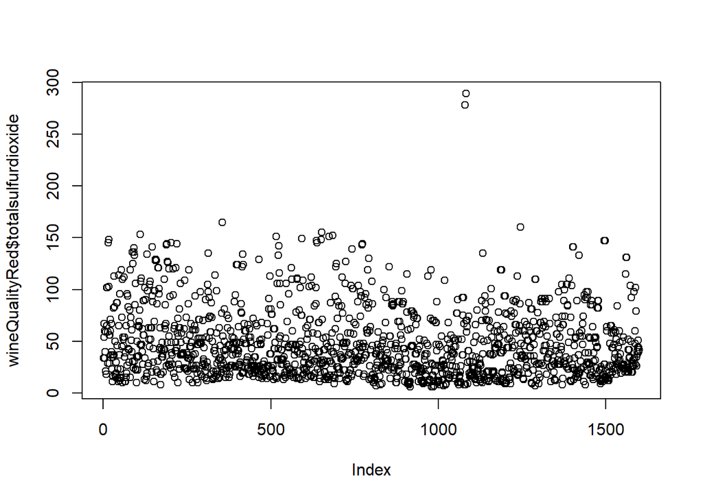

```r
plot(wineQualityRed$totalsulfurdioxide)
```

Aquests dos valors si que es veuen ben diferenciats de la resta. Mirem quina informació dóna la seva fila per veure si discernim si són valors correctes o incorrectes. El valor màxim és 289:

```r
wineQualityRed[wineQualityRed$totalsulfurdioxide==289,]
```

```
##      fixedacidity volatileacidity citricacid residualsugar chlorides
## 1082          7.9             0.3       0.68           8.3      0.05
##      freesulfurdioxide totalsulfurdioxide density   pH sulphates alcohol
## 1082              37.5                289 0.99316 3.01      0.51    12.3
##      quality
## 1082       7
```

```r
wineQualityRed[wineQualityRed$totalsulfurdioxide==278,]
```

```
##      fixedacidity volatileacidity citricacid residualsugar chlorides
## 1080          7.9             0.3       0.68           8.3      0.05
##      freesulfurdioxide totalsulfurdioxide density   pH sulphates alcohol
## 1080              37.5                278 0.99316 3.01      0.51    12.3
##      quality
## 1080       7
```

Els valors de totes les variables semblen normals per tant suposarem que els valors d’aquesta variable són correctes. Tal com comenta a:https://archive.ics.uci.edu/ml/datasets/wine+quality els algoritmes d’outliers poden ajudar a detectar els vins excelents o molt pobres i de fet es pot veure que aquests dos valors tenen qualitat = 7 que és alta. Veurem més endavant si aquesta variable té un pes important en la qualitat dels vins.

La resta de variables no sembla que presentin outliers. Hi ha alguns valors fora de la normalitat però no s’en veu cap sol i molt allunyat de tota la resta.

# 4. Anàlisi de les dades.

## 4.1. Selecció dels grups de dades que es volen analitzar/comparar.

Podem comprovar primerament la variable qualitat, que seria la variable que es voldria predir, la variable que ens mostra si un vi és o no és bo.

```r
summary(wineQualityRed$quality)
```

```
##    Min. 1st Qu.  Median    Mean 3rd Qu.    Max.
##   3.000   5.000   6.000   5.636   6.000   8.000
```

Veiem que la majoria dels vins són aprovats, la mitjana és 5.636 i la mediana 6. Serà més fàcil veure-ho amb representacions visuals.

```r
table(wineQualityRed$quality)
```

```
##
##   3   4   5   6   7   8
##  10  53 681 638 199  18
```

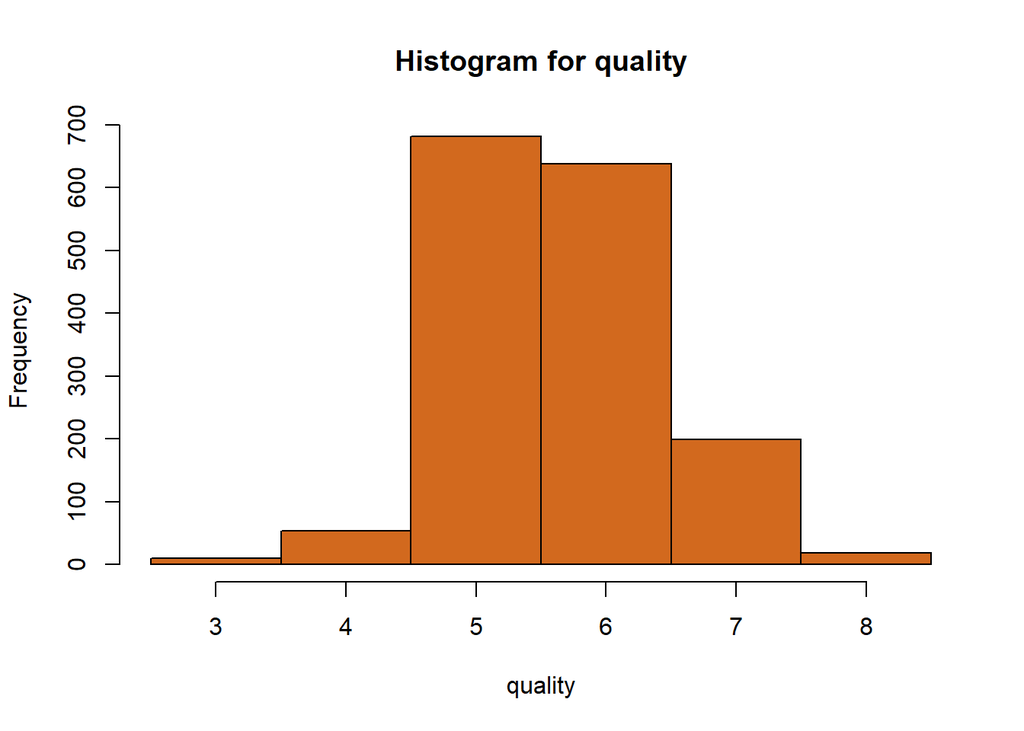

```r
hist(wineQualityRed$quality,
     main="Histogram for quality",
     xlab="quality",
     col="chocolate",
     breaks=seq(min(wineQualityRed$quality)-0.5, max(wineQualityRed$quality)+0.5))
```

Ja que agafem totes les variables, estaria bé analitzar-les totes.

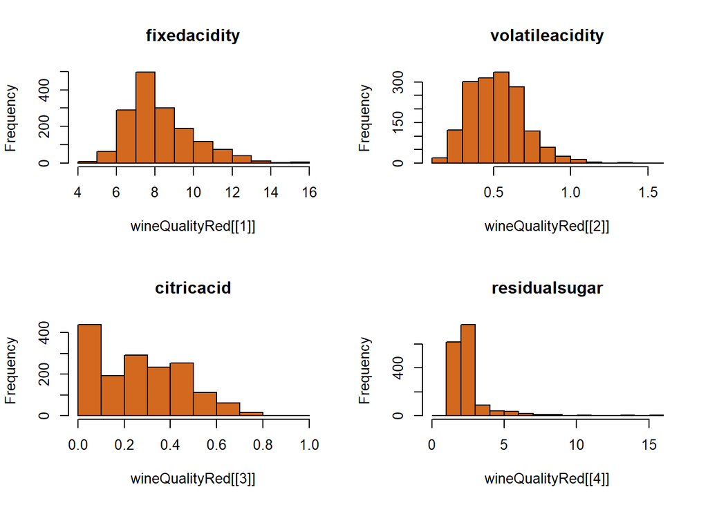

```r
par(mfrow = c(2,2))

hist(wineQualityRed[[1]],
     main=colnames(wineQualityRed)[1],
     col="chocolate")

hist(wineQualityRed[[2]],
     main=colnames(wineQualityRed)[2],
     col="chocolate")


hist(wineQualityRed[[3]],
     main=colnames(wineQualityRed)[3],
     col="chocolate")

hist(wineQualityRed[[4]],
     main=colnames(wineQualityRed)[4],
     col="chocolate")
```

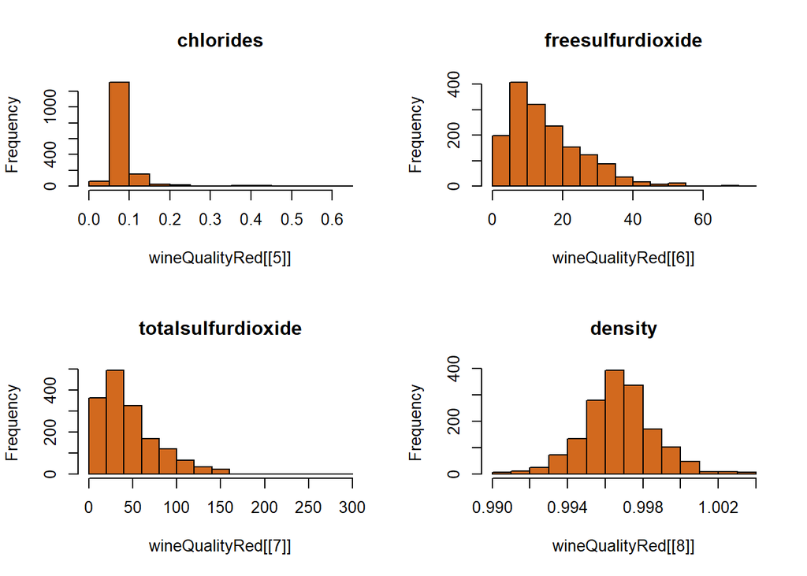

```r
par(mfrow = c(2,2))

hist(wineQualityRed[[5]],
     main=colnames(wineQualityRed)[5],
     col="chocolate")

hist(wineQualityRed[[6]],
     main=colnames(wineQualityRed)[6],
     col="chocolate")

hist(wineQualityRed[[7]],
     main=colnames(wineQualityRed)[7],
     col="chocolate")

hist(wineQualityRed[[8]],
     main=colnames(wineQualityRed)[8],
     col="chocolate")
```

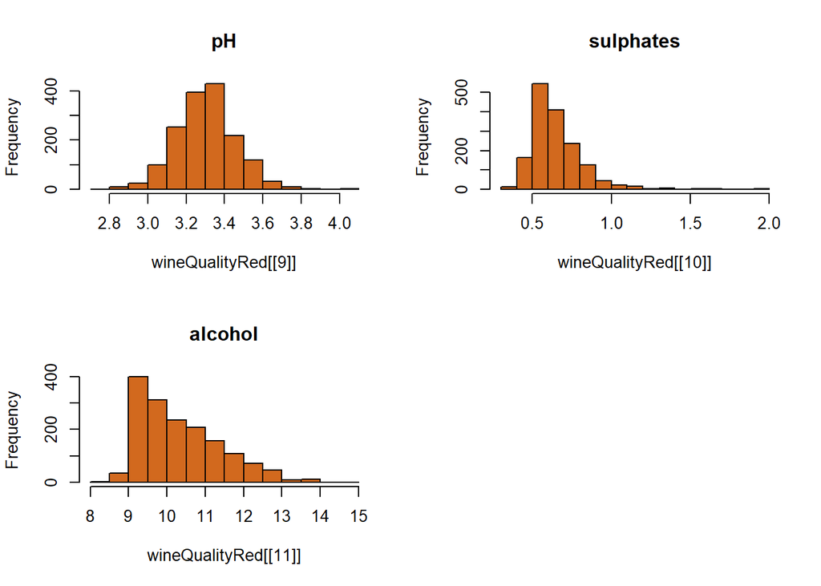

```r
par(mfrow = c(2,2))

hist(wineQualityRed[[9]],
     main=colnames(wineQualityRed)[9],
     col="chocolate")

hist(wineQualityRed[[10]],
     main=colnames(wineQualityRed)[10],
     col="chocolate")


hist(wineQualityRed[[11]],
     main=colnames(wineQualityRed)[11],
     col="chocolate")
```

## 4.2. Comprovació de la normalitat i homogeneïtat de la variància.

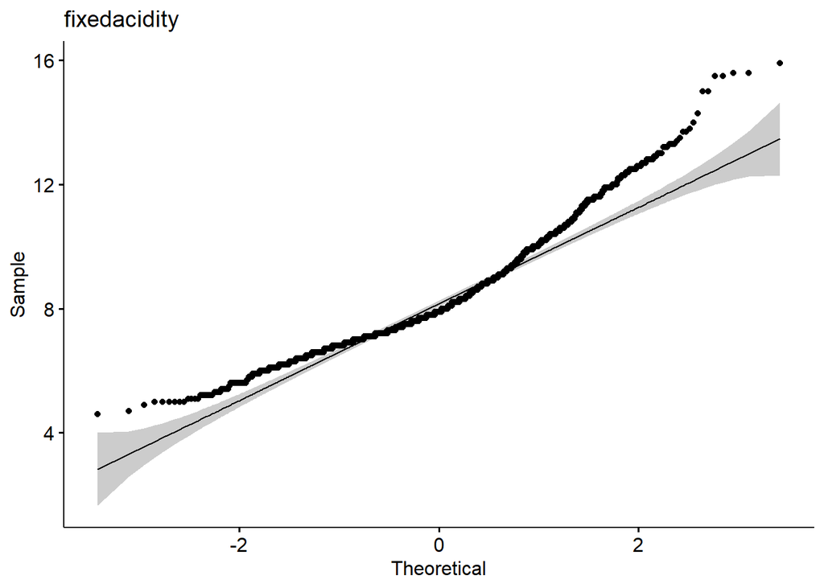

```r
library(ggpubr)


ggqqplot(wineQualityRed[[1]], title = colnames(wineQualityRed)[1])
```

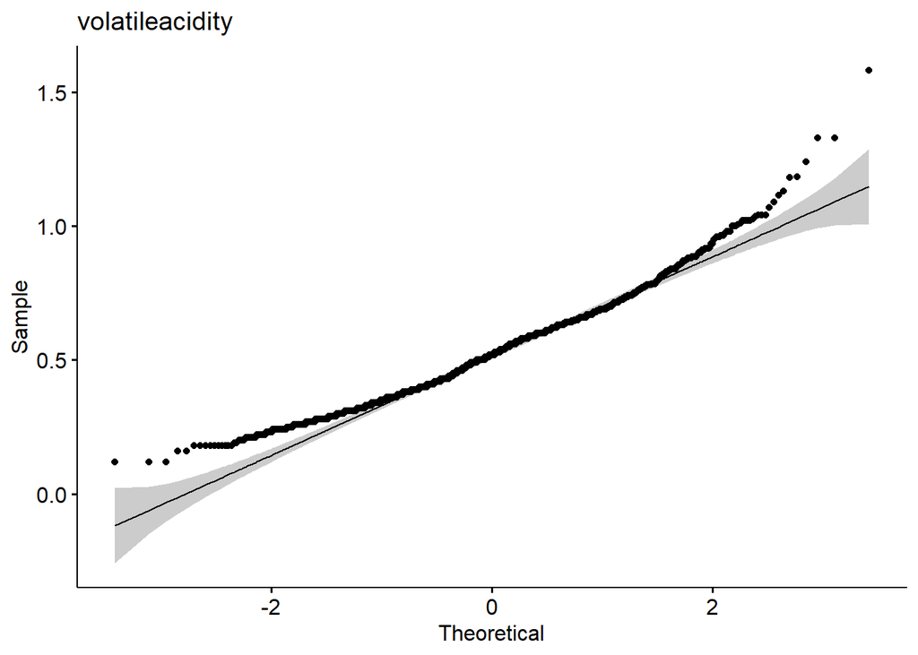

```r
ggqqplot(wineQualityRed[[2]], title = colnames(wineQualityRed)[2])
```

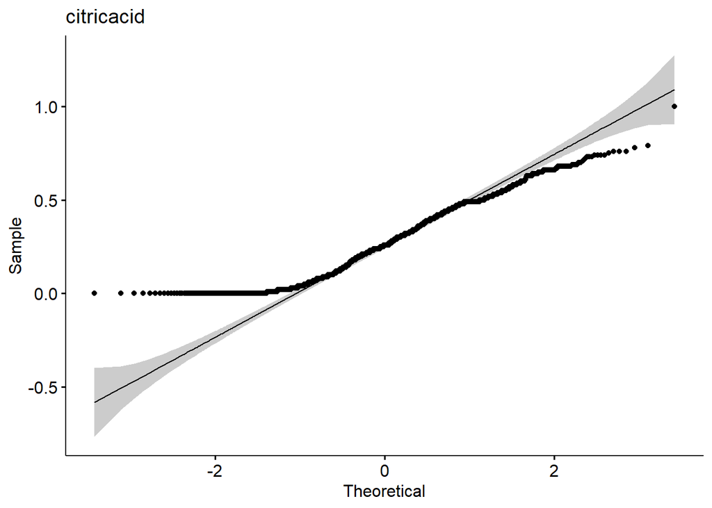

```r
ggqqplot(wineQualityRed[[3]], title = colnames(wineQualityRed)[3])
```

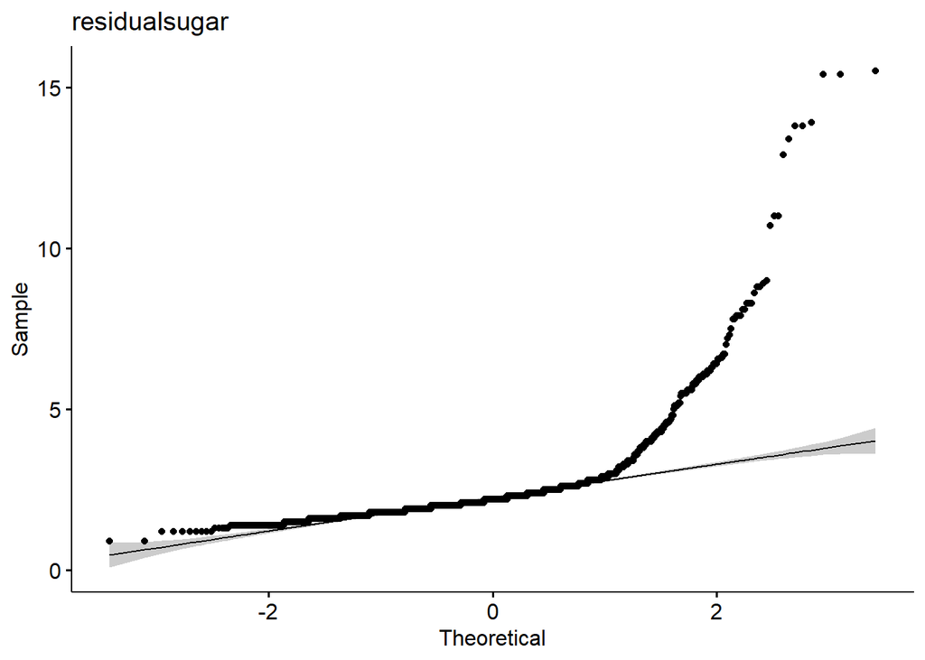

```r
ggqqplot(wineQualityRed[[4]], title = colnames(wineQualityRed)[4])
```

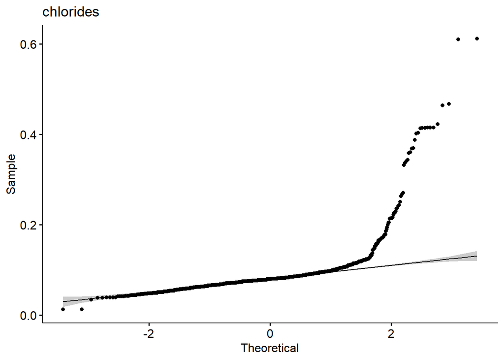

```r
ggqqplot(wineQualityRed[[5]], title = colnames(wineQualityRed)[5])
```

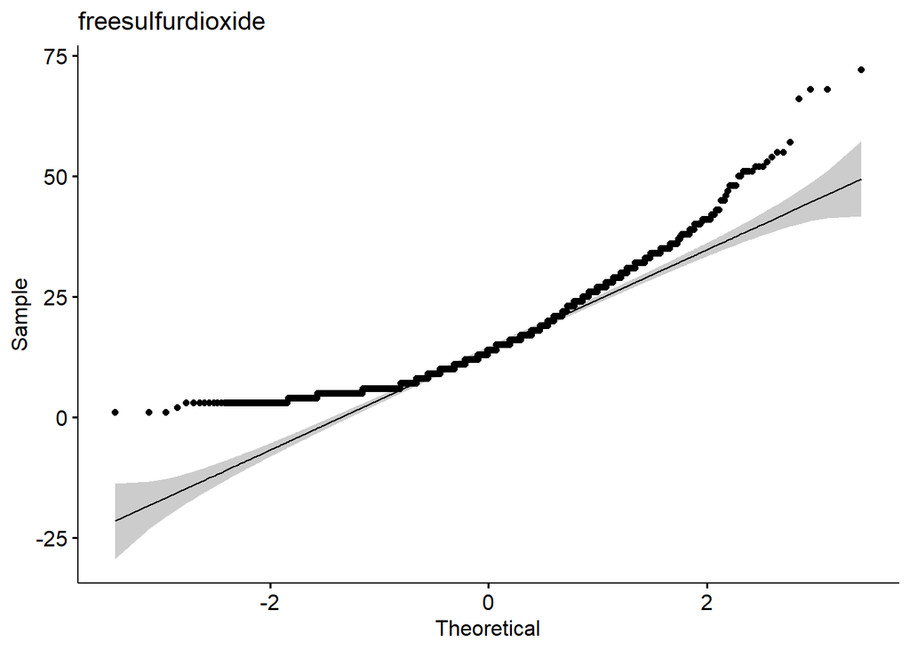

```r
ggqqplot(wineQualityRed[[6]], title = colnames(wineQualityRed)[6])
```

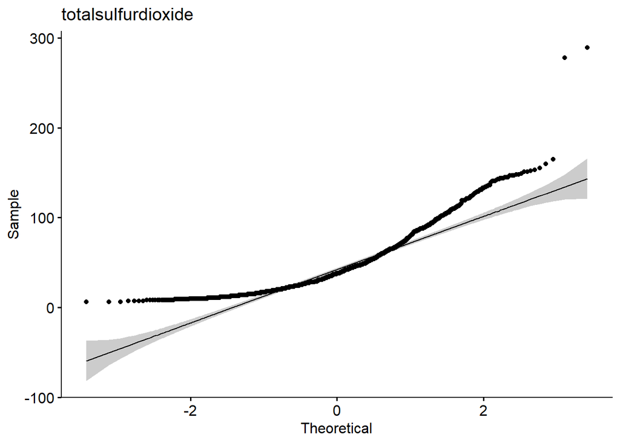

```r
ggqqplot(wineQualityRed[[7]], title = colnames(wineQualityRed)[7])
```

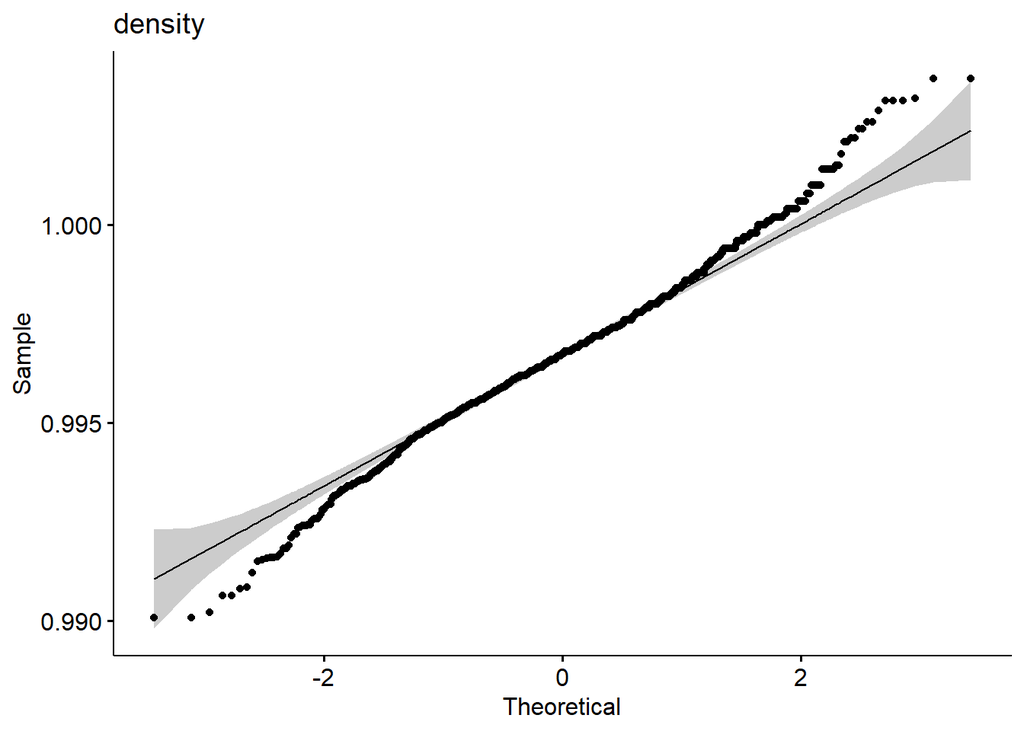

```r
ggqqplot(wineQualityRed[[8]], title = colnames(wineQualityRed)[8])
```

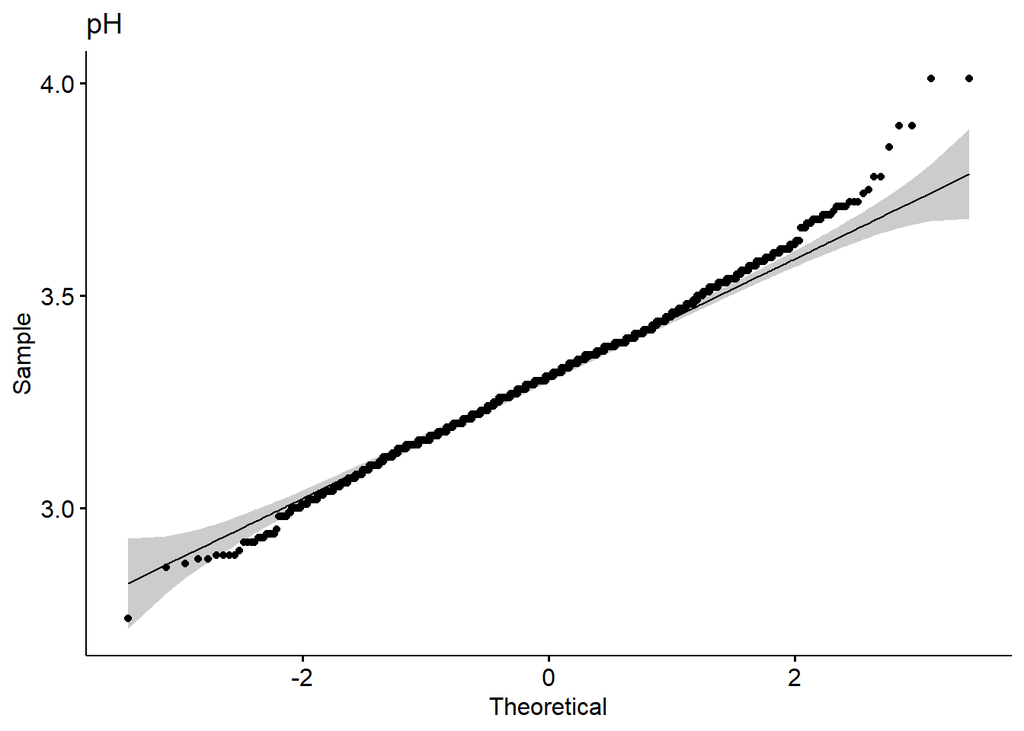

```r
ggqqplot(wineQualityRed[[9]], title = colnames(wineQualityRed)[9])
```

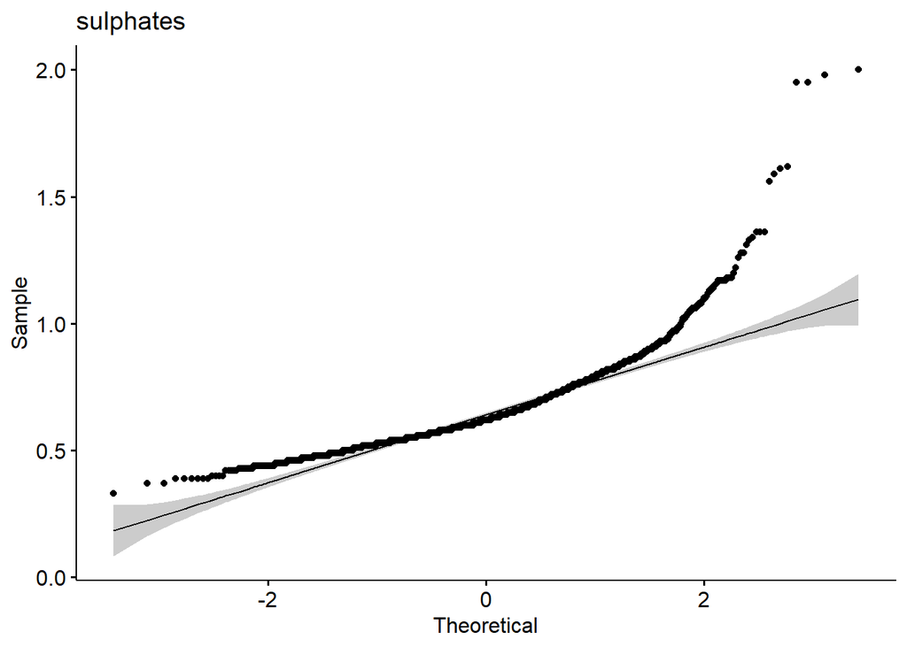

```r
ggqqplot(wineQualityRed[[10]], title = colnames(wineQualityRed)[10])
```

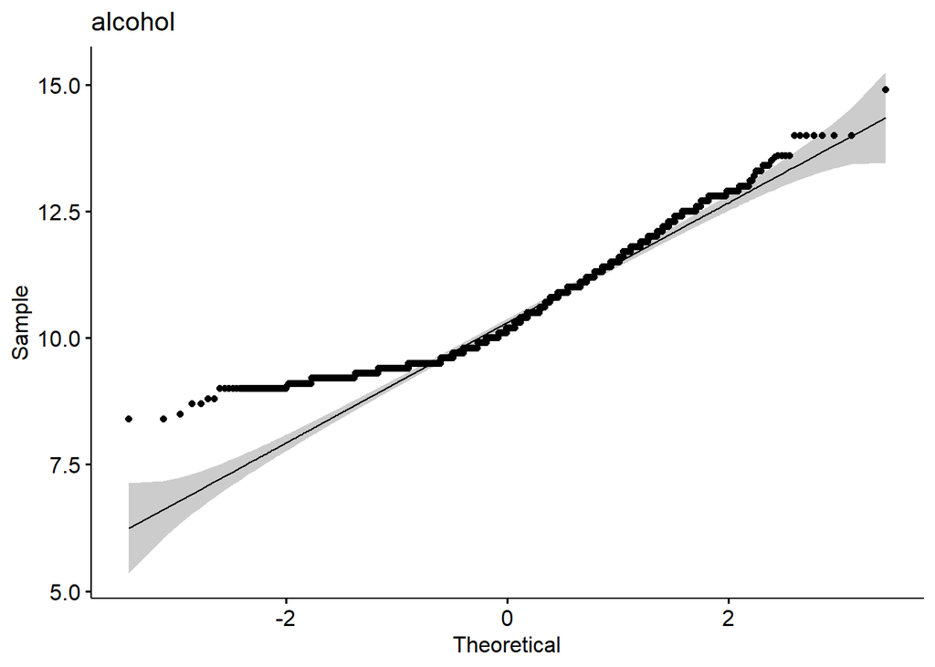

```r
ggqqplot(wineQualityRed[[11]], title = colnames(wineQualityRed)[11])
```

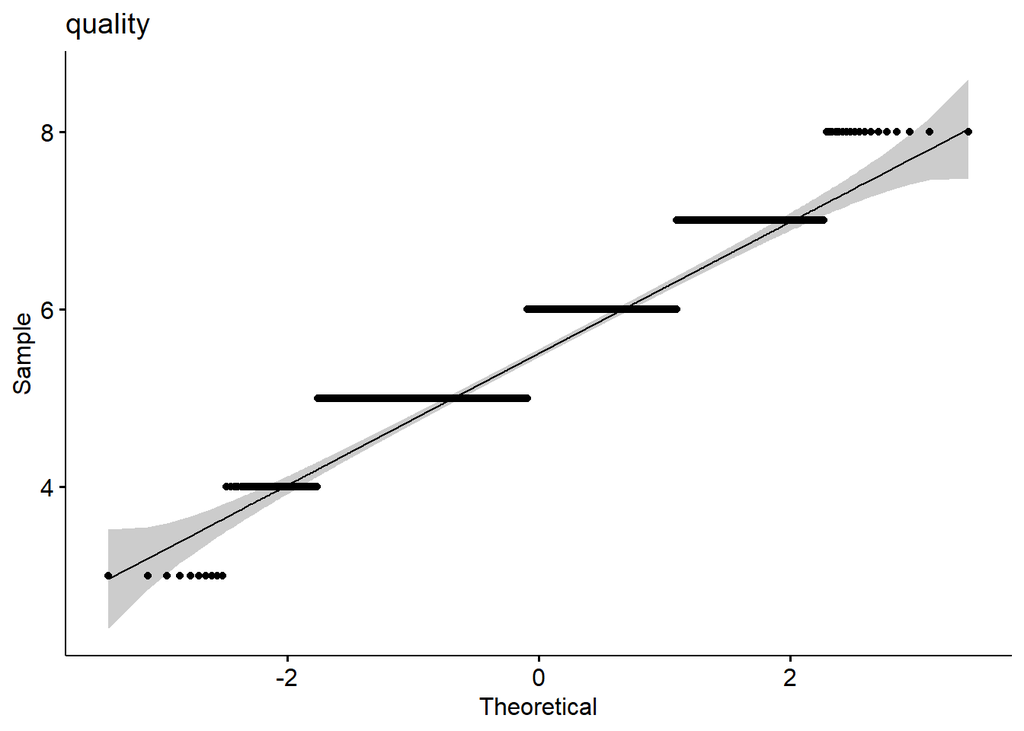

```r
ggqqplot(wineQualityRed[[12]], title = colnames(wineQualityRed)[12])
```

Tot i que la majoria de variables intenten seguir la línea recta, els punts no són dins de la zona grisa. Això vol dir que les variables no segueixen la normalitat.

Si mirem el test de shapiro per extreure’n la p-value:

```r
shapiro.test(wineQualityRed[[1]])
```

```
##
##  Shapiro-Wilk normality test
##
## data:  wineQualityRed[[1]]
## W = 0.94203, p-value < 2.2e-16
```

```r
shapiro.test(wineQualityRed[[2]])
```

```
##
##  Shapiro-Wilk normality test
##
## data:  wineQualityRed[[2]]
## W = 0.97434, p-value = 2.693e-16
```

```r
shapiro.test(wineQualityRed[[3]])
```

```
##
##  Shapiro-Wilk normality test
##
## data:  wineQualityRed[[3]]
## W = 0.95529, p-value < 2.2e-16
```

```r
shapiro.test(wineQualityRed[[4]])
```

```
##
##  Shapiro-Wilk normality test
##
## data:  wineQualityRed[[4]]
## W = 0.56608, p-value < 2.2e-16
```

```r
shapiro.test(wineQualityRed[[5]])
```

```
##
##  Shapiro-Wilk normality test
##
## data:  wineQualityRed[[5]]
## W = 0.48425, p-value < 2.2e-16
```

```r
shapiro.test(wineQualityRed[[6]])
```

```
##
##  Shapiro-Wilk normality test
##
## data:  wineQualityRed[[6]]
## W = 0.90184, p-value < 2.2e-16
```

```r
shapiro.test(wineQualityRed[[7]])
```

```
##
##  Shapiro-Wilk normality test
##
## data:  wineQualityRed[[7]]
## W = 0.87322, p-value < 2.2e-16
```

```r
shapiro.test(wineQualityRed[[8]])
```

```
##
##  Shapiro-Wilk normality test
##
## data:  wineQualityRed[[8]]
## W = 0.99087, p-value = 1.936e-08
```

```r
shapiro.test(wineQualityRed[[9]])
```

```
##
##  Shapiro-Wilk normality test
##
## data:  wineQualityRed[[9]]
## W = 0.99349, p-value = 1.712e-06
```

```r
shapiro.test(wineQualityRed[[10]])
```

```
##
##  Shapiro-Wilk normality test
##
## data:  wineQualityRed[[10]]
## W = 0.83304, p-value < 2.2e-16
```

```r
shapiro.test(wineQualityRed[[11]])
```

```
##
##  Shapiro-Wilk normality test
##
## data:  wineQualityRed[[11]]
## W = 0.92884, p-value < 2.2e-16
```

```r
shapiro.test(wineQualityRed[[12]])
```

```
##
##  Shapiro-Wilk normality test
##
## data:  wineQualityRed[[12]]
## W = 0.85759, p-value < 2.2e-16
```

Cridant al shapiro test, també veiem que la p-value és més baixa del 5% de grau de confiança (0.05). Tornem a concluir que ninguna variable segueix una normalitat estricta.

Per últim comprovarem la normalitat amb el test de Anderson-Darling per totes les variables:

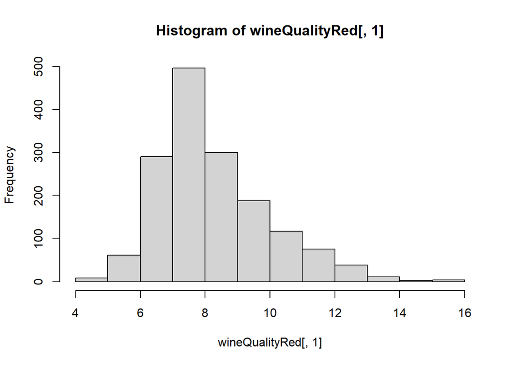

```r
library(nortest)

hist(wineQualityRed[,1])
```

```r
ad.test(wineQualityRed[,1])
```

```
##
##  Anderson-Darling normality test
##
## data:  wineQualityRed[, 1]
## A = 28.143, p-value < 2.2e-16
```

```r
alpha <- 0.05
col.names = colnames(wineQualityRed)

for (i in 1:ncol(wineQualityRed)) {

   if (is.integer(wineQualityRed[,i]) | is.numeric(wineQualityRed[,i])) {
      p_val = ad.test(wineQualityRed[,i])$p.value
      if (p_val < alpha) {
       cat("No Normal: ") + cat(col.names[i]) + cat("- p-value:") + cat(p_val) + cat("\n")
      }
      else {
         cat ("Normal: ") + cat(col.names[i]) + cat("- p-value:") + cat(p_val) + cat("\n")
      }
   }
}
```

```
## No Normal: fixedacidity- p-value:3.7e-24
## No Normal: volatileacidity- p-value:5.318894e-14
## No Normal: citricacid- p-value:3.7e-24
## No Normal: residualsugar- p-value:3.7e-24
## No Normal: chlorides- p-value:3.7e-24
## No Normal: freesulfurdioxide- p-value:3.7e-24
## No Normal: totalsulfurdioxide- p-value:3.7e-24
## No Normal: density- p-value:1.227494e-09
## No Normal: pH- p-value:9.245208e-05
## No Normal: sulphates- p-value:3.7e-24
## No Normal: alcohol- p-value:3.7e-24
## No Normal: quality- p-value:3.7e-24
```

Segons el test d’Anderson-Darling no hi ha cap variable que segueixi una distribució normal.

## 4.3. Aplicació de proves estadístiques per comparar els grups de dades.

### Regressió lineal simple.

Começarem per aplicar una regressió lineal per veure la relació entre dues variables, podem començar per les variables quality i alcohol.

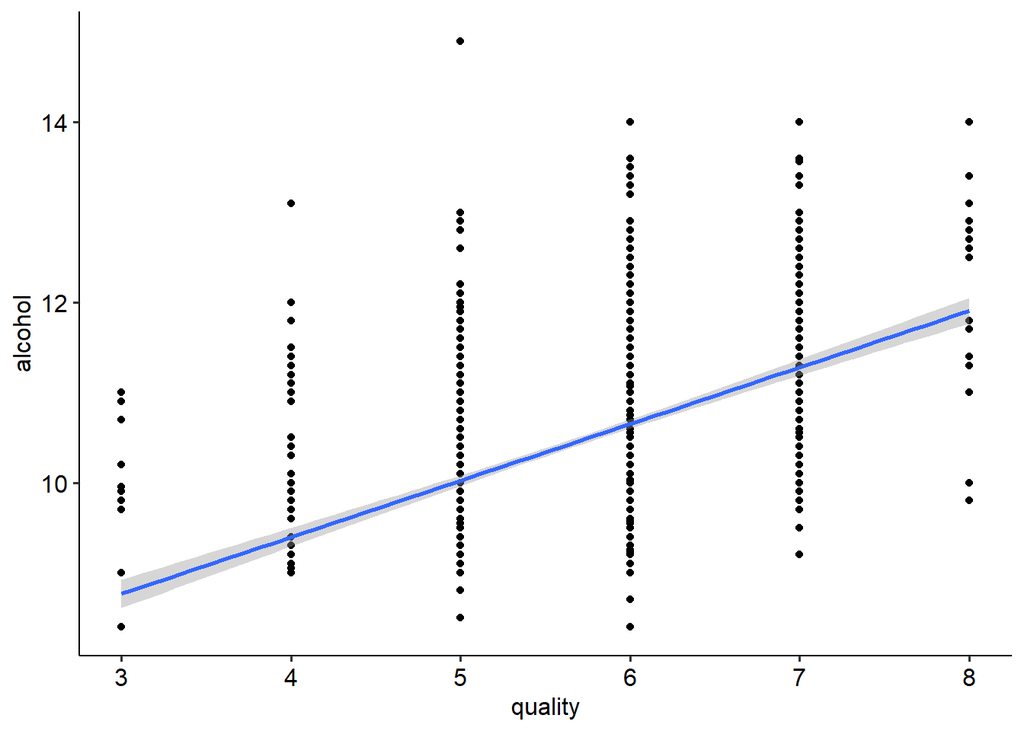

```r
library(ggpubr)
theme_set(theme_pubr())

ggplot(wineQualityRed, aes(x = quality, y = alcohol)) + geom_point() + stat_smooth(method = lm)
```

Els punts s’allunyen molt de la línea recta, aquesta regressió no és bona per una variable entera com la qualitat respecte una double en un rang determinat.

```r
mod<-lm(quality ~ alcohol, wineQualityRed)
summary(mod)
```

```
##
## Call:
## lm(formula = quality ~ alcohol, data = wineQualityRed)
##
## Residuals:
##     Min      1Q  Median      3Q     Max
## -2.8442 -0.4112 -0.1690  0.5166  2.5888
##
## Coefficients:
##             Estimate Std. Error t value Pr(>|t|)
## (Intercept)  1.87497    0.17471   10.73   <2e-16 ***
## alcohol      0.36084    0.01668   21.64   <2e-16 ***
## ---
## Signif. codes:  0 '***' 0.001 '**' 0.01 '*' 0.05 '.' 0.1 ' ' 1
##
## Residual standard error: 0.7104 on 1597 degrees of freedom
## Multiple R-squared:  0.2267, Adjusted R-squared:  0.2263
## F-statistic: 468.3 on 1 and 1597 DF,  p-value: < 2.2e-16
```

Si probem amb comparant altres variables:

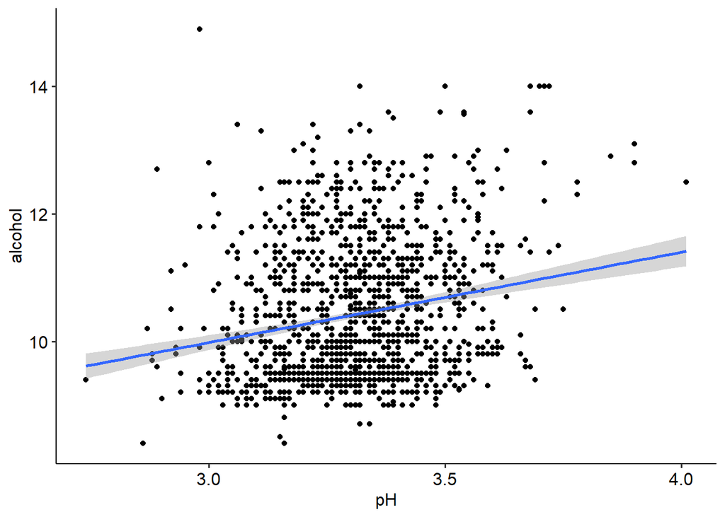

```r
ggplot(wineQualityRed, aes(x = pH, y = alcohol)) + geom_point() + stat_smooth(method = lm)
```

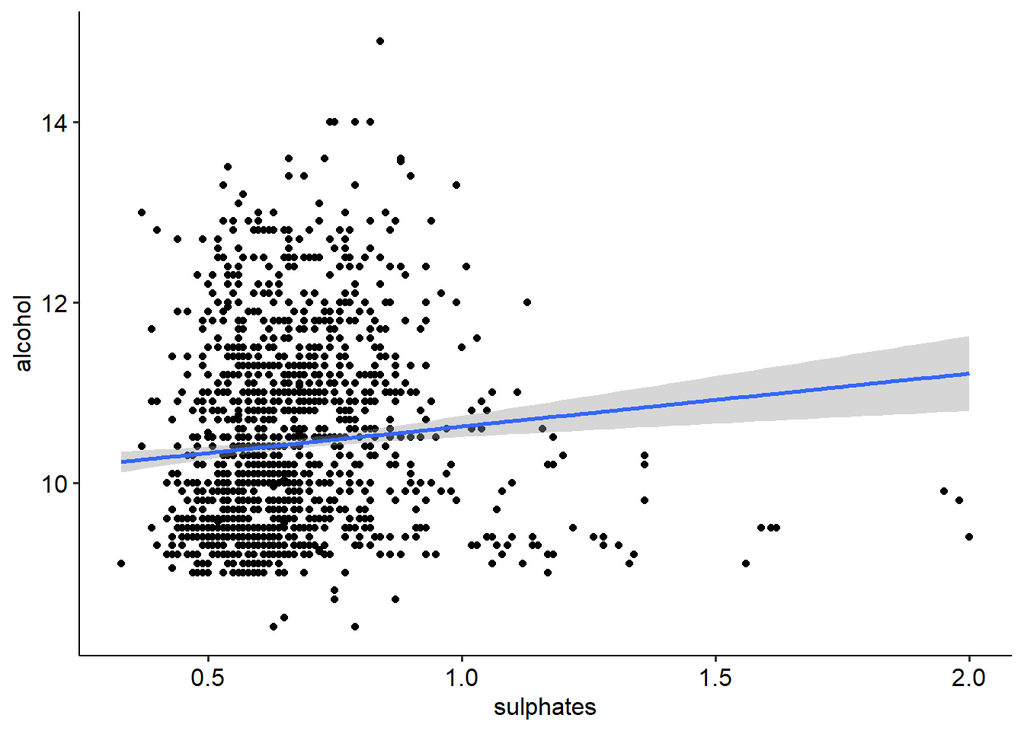

```r
ggplot(wineQualityRed, aes(x = sulphates, y = alcohol)) + geom_point() + stat_smooth(method = lm)
```

Veiem que no tenen massa relació entre elles, almenys fent regressions lineals.

### Regressió lineal múltiple.

Si probem amb una regressió lineal múltiple, amb la variable quality més alcohol i pH:

```r
mod <- lm(quality ~ alcohol + pH, data = wineQualityRed)

summary(mod)
```

```
##
## Call:
## lm(formula = quality ~ alcohol + pH, data = wineQualityRed)
##
## Residuals:
##     Min      1Q  Median      3Q     Max
## -2.7153 -0.4066 -0.1105  0.5076  2.4584
##
## Coefficients:
##             Estimate Std. Error t value Pr(>|t|)
## (Intercept)  4.42581    0.38742  11.424  < 2e-16 ***
## alcohol      0.38617    0.01676  23.036  < 2e-16 ***
## pH          -0.85011    0.11571  -7.347 3.23e-13 ***
## ---
## Signif. codes:  0 '***' 0.001 '**' 0.01 '*' 0.05 '.' 0.1 ' ' 1
##
## Residual standard error: 0.6989 on 1596 degrees of freedom
## Multiple R-squared:  0.252,  Adjusted R-squared:  0.2511
## F-statistic: 268.9 on 2 and 1596 DF,  p-value: < 2.2e-16
```

Veiem que tampoc existeix massa relació.

### Busquem les correlacions que hi ha entre variables

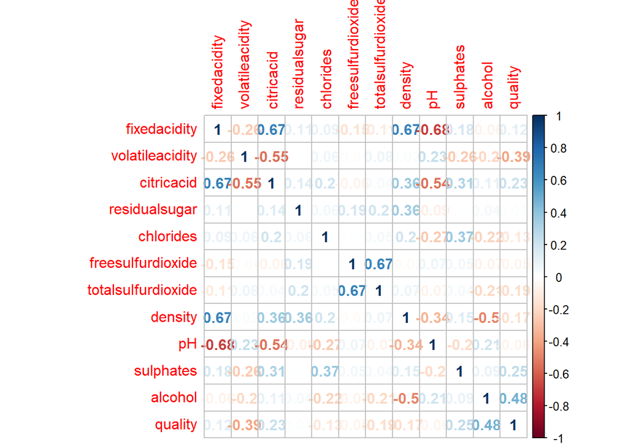

```r
par(mfrow = c(1,1))
correlacio.wineQualityRed <- cor(wineQualityRed)
corrplot(correlacio.wineQualityRed, method = 'number')
```

```r
cat("\n")
```

Les variables que estàn més correlacioandes entre elles són pH i fixedAxcidity. Les següents més relacionades són:

- fixedAcidity i citricAcid
- fixedACidity i density
- freeSulfurDioxide i totalSulfurDioxide

I les variables que estàn més relacionades amb la qualitat són:

- alcohol
- volatileacidity

### Knn

Per intentar predir la qualitat del vi segons els variables que tenim d’entrada, aplicarem l’algoritme K-Nearest Neighbors (Knn)

Per tal de poder classificar més fàcilment el primer que farem és dicretitzar la variable qualitat. Tenint en compte que el que volem és saber si el vi tindrpa qualitat alta o baixa per discretitzarem utitilitzant intervals lògics.Tindrem els següents nivells:

Qualitat:

- < 5 -> Baixa
- 5-> Mitja baixa
- 6 -> Mitja alta
- “>” 6 -> Alta

Separem mitja baixa i mitja alta perquè la major part dels registres es troben en aquests dos valors.

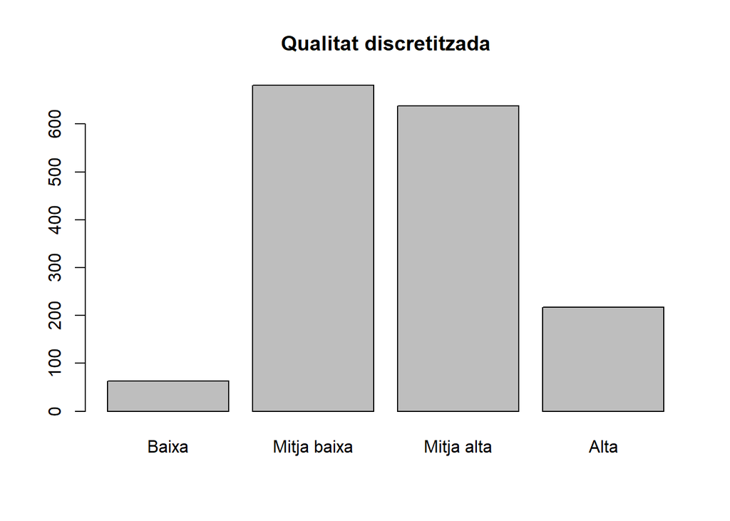

```r
breaks1 <- c(0,4,5,6,10)
c <- cut(wineQualityRed$quality,breaks=breaks1, labels = c('Baixa','Mitja baixa','Mitja alta','Alta'))

wineQualityRedD<- wineQualityRed
wineQualityRedD$quality<- c

plot(wineQualityRedD$quality, main = "Qualitat discretitzada")
```

```r
summary(wineQualityRedD$quality)
```

```
##       Baixa Mitja baixa  Mitja alta        Alta
##          63         681         638         217
```

Separarem el dataset en dos datasets, un per entrenar el nostre algoritme (train) i un per testajar com de vàlid és el nostre algoritme (test). Agafarem 2/3 de les dades per crear el conjunt d’entrenament i 1/3 pel conjunt de test.

També separarem la variable de sortida

```r
set.seed(200)
y <- wineQualityRedD[,12]
X <- wineQualityRedD[,1:11]

set.seed(300)

indexes = sample(1:nrow(wineQualityRedD),size=floor((2/3)*nrow(wineQualityRedD)))

trainMX <- X[indexes,]
trainMy <- y[indexes]
testMX  <- X[-indexes,]
testMy  <- y[-indexes]
```

Comprovem si les dades entre el set de train i de test shan quedat ben repartides.

```r
prop.table(table(trainMy))
```

```
## trainMy
##       Baixa Mitja baixa  Mitja alta        Alta
##  0.04033771  0.42401501  0.39587242  0.13977486
```

```r
prop.table(table(testMy))
```

```
## testMy
##       Baixa Mitja baixa  Mitja alta        Alta
##  0.03752345  0.42964353  0.40525328  0.12757974
```

Veiem que sí que es troben ben proporcionats, els porcentatges de vins amb qualitat alta, mitja alta, mitja baixa i baixa són semblants en els dos sets de dades.

Escalarem les variables ja que es troben en escales diferents. Calculem K com l’arrel quadrada del número d’observacions (1599).

```r
library (class)
library (caret)
wineTrain.Scal <- scale(trainMX, center = TRUE, scale = TRUE)
wineTest.Scal <- scale(testMX, center = TRUE, scale = TRUE)



set.seed(678)

wine.knn<- knn(train = wineTrain.Scal, test=wineTest.Scal, cl=trainMy, k=40)
```

Evaluarem el rendiment del model

```r
confusionMatrix(testMy, wine.knn)
```

```
## Confusion Matrix and Statistics
##
##              Reference
## Prediction    Baixa Mitja baixa Mitja alta Alta
##   Baixa           0          16          4    0
##   Mitja baixa     0         174         51    4
##   Mitja alta      0          72        126   18
##   Alta            0           3         46   19
##
## Overall Statistics
##
##                Accuracy : 0.5985
##                  95% CI : (0.5555, 0.6404)
##     No Information Rate : 0.4972
##     P-Value [Acc > NIR] : 1.675e-06
##
##                   Kappa : 0.3352
##
##  Mcnemar's Test P-Value : NA
##
## Statistics by Class:
##
##                      Class: Baixa Class: Mitja baixa Class: Mitja alta
## Sensitivity                    NA             0.6566            0.5551
## Specificity               0.96248             0.7948            0.7059
## Pos Pred Value                 NA             0.7598            0.5833
## Neg Pred Value                 NA             0.7007            0.6814
## Prevalence                0.00000             0.4972            0.4259
## Detection Rate            0.00000             0.3265            0.2364
## Detection Prevalence      0.03752             0.4296            0.4053
## Balanced Accuracy              NA             0.7257            0.6305
##                      Class: Alta
## Sensitivity              0.46341
## Specificity              0.90041
## Pos Pred Value           0.27941
## Neg Pred Value           0.95269
## Prevalence               0.07692
## Detection Rate           0.03565
## Detection Prevalence     0.12758
## Balanced Accuracy        0.68191
```

Provem sense factoritzar la variable de sortida a veure si tenim una predicció millor

```r
set.seed(300)

y2 <- wineQualityRed[,12]
X2 <- wineQualityRed[,1:11]

set.seed(456)

indexes2 = sample(1:nrow(wineQualityRed),size=floor((2/3)*nrow(wineQualityRed)))

trainMX2 <- X2[indexes2,]
trainMy2 <- y2[indexes2]
testMX2  <- X2[-indexes2,]
testMy2  <- y2[-indexes2]

prop.table(table(trainMy2))
```

```
## trainMy2
##           3           4           5           6           7           8
## 0.005628518 0.033771107 0.417448405 0.399624765 0.131332083 0.012195122
```

```r
prop.table(table(testMy2))
```

```
## testMy2
##           3           4           5           6           7           8
## 0.007504690 0.031894934 0.442776735 0.397748593 0.110694184 0.009380863
```

```r
wineTrain.Scal2 <- scale(trainMX2, center = TRUE, scale = TRUE)
wineTest.Scal2 <- scale(testMX2, center = TRUE, scale = TRUE)

set.seed(555)

wine.knn2<- knn(train = wineTrain.Scal2, test=wineTest.Scal2, cl=trainMy2, k=40)
```

Evaluarem el rendiment del model

```r
confusionMatrix(factor(testMy2), wine.knn2)
```

```
## Confusion Matrix and Statistics
##
##           Reference
## Prediction   3   4   5   6   7   8
##          3   0   0   3   1   0   0
##          4   0   0  12   5   0   0
##          5   0   0 163  70   3   0
##          6   0   0  55 133  24   0
##          7   0   0   5  35  19   0
##          8   0   0   0   3   2   0
##
## Overall Statistics
##
##                Accuracy : 0.591
##                  95% CI : (0.5479, 0.6331)
##     No Information Rate : 0.4634
##     P-Value [Acc > NIR] : 2.335e-09
##
##                   Kappa : 0.3273
##
##  Mcnemar's Test P-Value : NA
##
## Statistics by Class:
##
##                      Class: 3 Class: 4 Class: 5 Class: 6 Class: 7 Class: 8
## Sensitivity                NA       NA   0.6849   0.5385  0.39583       NA
## Specificity          0.992495  0.96811   0.7525   0.7238  0.91753 0.990619
## Pos Pred Value             NA       NA   0.6907   0.6274  0.32203       NA
## Neg Pred Value             NA       NA   0.7475   0.6449  0.93882       NA
## Prevalence           0.000000  0.00000   0.4465   0.4634  0.09006 0.000000
## Detection Rate       0.000000  0.00000   0.3058   0.2495  0.03565 0.000000
## Detection Prevalence 0.007505  0.03189   0.4428   0.3977  0.11069 0.009381
## Balanced Accuracy          NA       NA   0.7187   0.6311  0.65668       NA
```

El resultat ha estat quasi el mateix. La predicció és del 59 % que és molt baix. Així que no és un model molt bo per esbrinar la qualitat del vi segons les variables d’entrada.

El valor de Kappa és també molt baix, 33 % i ens reforça encara més la idea que aquest model no ens és massa útil.

## Arbres de decisió.

Un altre métode, fàcil per a predir una variable en concret.

Bàsicament crearà un arbre binari, respecte als atributs del dataset, plantejarà condicions i depenent si la resposta és veritat o mentida (boolean), seguirà un camí o un altre.

Finalment, al arribar a la fulla, es podrà predir, en aquest cas, la puntuació d’un vi.

```r
#install.packages(rpart)
#install.packages(rpart.plot)
library(rpart)
library(rpart.plot)

decisionTreesPart <- rpart(quality ~. , data = wineQualityRed)
decisionTreesPart
```

```
## n= 1599
##
## node), split, n, deviance, yval
##       * denotes terminal node
##
##  1) root 1599 1042.16500 5.636023
##    2) alcohol< 10.525 983  424.15870 5.366226
##      4) sulphates< 0.575 391  128.09720 5.150895 *
##      5) sulphates>=0.575 592  265.95780 5.508446
##       10) volatileacidity>=0.405 448  175.87280 5.404018 *
##       11) volatileacidity< 0.405 144   70.00000 5.833333 *
##    3) alcohol>=10.525 616  432.27110 6.066558
##      6) sulphates< 0.645 272  191.86760 5.727941
##       12) volatileacidity>=1.015 10    6.00000 4.000000 *
##       13) volatileacidity< 1.015 262  154.87020 5.793893
##         26) volatileacidity>=0.495 146   73.67123 5.575342 *
##         27) volatileacidity< 0.495 116   65.44828 6.068966 *
##      7) sulphates>=0.645 344  184.55520 6.334302
##       14) alcohol< 11.55 206  101.96600 6.121359
##         28) volatileacidity>=0.395 111   37.42342 5.927928 *
##         29) volatileacidity< 0.395 95   55.53684 6.347368
##           58) pH>=3.255 59   29.72881 6.067797 *
##           59) pH< 3.255 36   13.63889 6.805556 *
##       15) alcohol>=11.55 138   59.30435 6.652174 *
```

Representació de l’arbre:

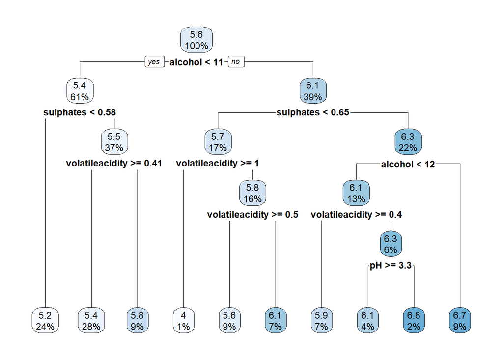

```r
rpart.plot(decisionTreesPart)
```

Partirem el dataset en dues parts, una per entrenar l’algorisme, un altre de més petit per a comprovar si les prediccions són prou correctes.

```r
train <- wineQualityRed[1:3750, ]
test <- wineQualityRed[3751:4898, ]
```

```r
predicted <- predict(decisionTreesPart, test)
summary(predicted)
```

```
##    Min. 1st Qu.  Median    Mean 3rd Qu.    Max.
##   5.404   5.404   5.404   5.404   5.404   5.404
```

El resultat predit, de mitjana la seva mediana és una puntuació de 5.4, no varia gaire.

```r
summary(wineQualityRed$quality)
```

```
##    Min. 1st Qu.  Median    Mean 3rd Qu.    Max.
##   3.000   5.000   6.000   5.636   6.000   8.000
```

Si ho comparem amb els resultats reals, veiem que la mitjana s’acosta, però és molt més variable el real.

Si agafem una mostra d’un vi inventada,

```r
test <- data.frame(fixedacidity = 8, volatileacidity = 0.3, citricacid = 0.42, residualsugar = 10.5, chlorides = 0.1, freesulfurdioxide = 47, totalsulfurdioxide = 186, density = 0.9955, pH = 3.10, sulphates = 0.90, alcohol = 13)

test
```

```
##   fixedacidity volatileacidity citricacid residualsugar chlorides
## 1            8             0.3       0.42          10.5       0.1
##   freesulfurdioxide totalsulfurdioxide density  pH sulphates alcohol
## 1                47                186  0.9955 3.1       0.9      13
```

Volem predir la puntuació d’aquest vi inventat,

```r
test_pred <- predict(decisionTreesPart, test)
test_pred
```

```
##        1
## 6.652174
```

Aquest vi, ens dona una puntuació de 6.65.

## Random Forests.

Una petita millora, s’aconsegueix amb l’algorisme de random forests. És un algorisme que bàsicament és acumular diferents random forests per aconseguir millor accuracy.

Primerament, és recomenable crear un nou atribut on, depenent de la qualitat del vi, el calssifiquem com a bo, normal o dolent. Així ens serà molt més fàcil de predir la seva qualitat amb aquest algorisme.

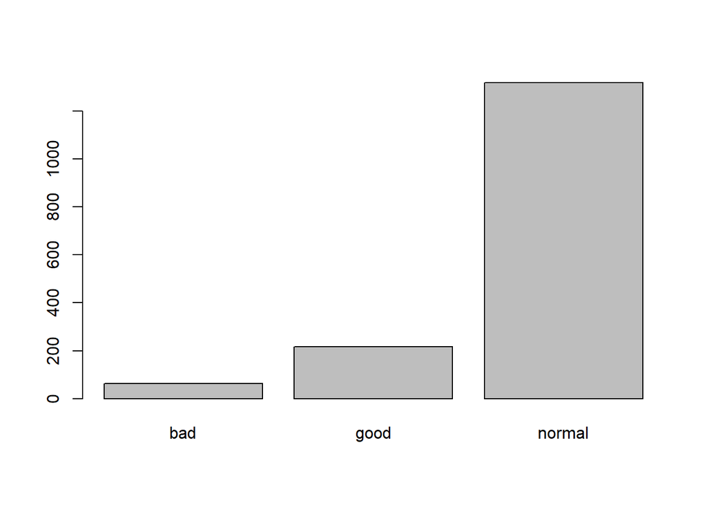

```r
wineQualityRed$taste <- ifelse(wineQualityRed$quality < 5, "bad", "good")
wineQualityRed$taste[wineQualityRed$quality == 5] <- "normal"
wineQualityRed$taste[wineQualityRed$quality == 6] <- "normal"
wineQualityRed$taste <- as.factor(wineQualityRed$taste)
barplot(table(wineQualityRed$taste))
```

Montarem millor el nostre train i test (80% i 20% respectivament). Aplicarem l’algorisme i farem una primera predicció.

```r
library(randomForest)
ind <- sample(2, nrow(wineQualityRed), replace = TRUE, prob=c(0.8, 0.2))
rf <- randomForest(taste ~ . - quality, data=wineQualityRed[ind == 1,])
pred <- predict(rf, wineQualityRed[ind == 2,])

rf
```

```
##
## Call:
##  randomForest(formula = taste ~ . - quality, data = wineQualityRed[ind ==      1, ])
##                Type of random forest: classification
##                      Number of trees: 500
## No. of variables tried at each split: 3
##
##         OOB estimate of  error rate: 12.99%
## Confusion matrix:
##        bad good normal class.error
## bad      0    1     47  1.00000000
## good     0   93     84  0.47457627
## normal   1   32   1012  0.03157895
```

```r
table(pred, data=wineQualityRed[ind == 2,]$taste)
```

```
##         data
## pred     bad good normal
##   bad      0    0      0
##   good     0   22     16
##   normal  15   18    258
```

Mirem la taula de predicció del test, semblant a la del train.

Calculem l’accuracy:

```r
sum(pred==wineQualityRed[ind == 2,]$taste) / nrow(wineQualityRed[ind == 2,])
```

```
## [1] 0.8510638
```

Obtenim una predicció amb un acert del 85%.

# 5. Representació dels resultats a partir de taules i gràfiques.

La principal taula, la més important d’aquest data set, és, sens dubte, la de l’atribut de qualitat.

Aquest atribut ja ens ve donat pel dataset per defecte, normalment aquest dataset s’utilitza per a crear models de preducció, especialment per a predir aquest atribut.

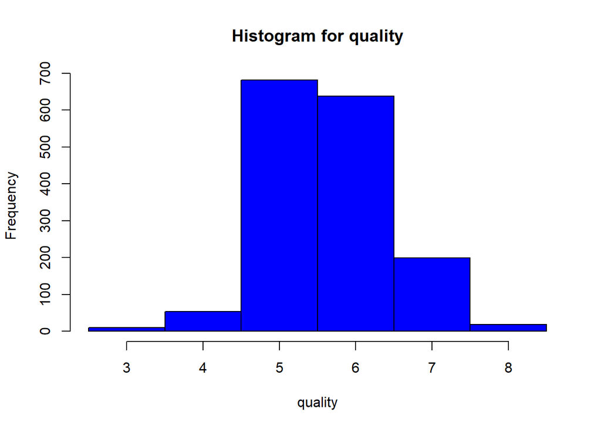

```r
hist(wineQualityRed$quality,
     main="Histogram for quality",
     xlab="quality",
     col="blue",
     breaks=seq(min(wineQualityRed$quality)-0.5, max(wineQualityRed$quality)+0.5))
```

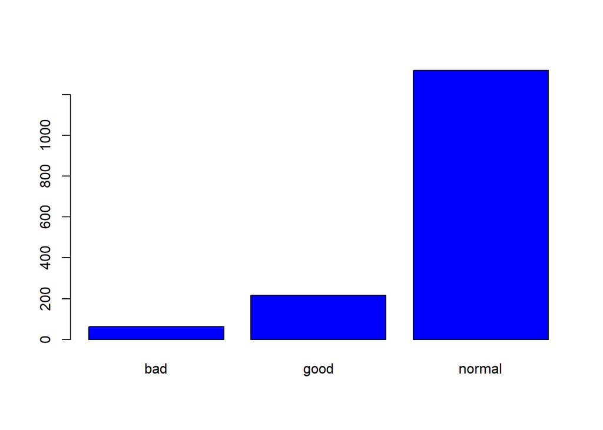

```r
barplot(table(wineQualityRed$taste), col="blue")
```

És curiós com la gran majoria de puntuació de qualitat estan compresses entre el 5 i el 6.

Després de comprovar que les dades no contenien valors nuls hem comprovat els outliers. Pel que hem vist, hem trobat alguns valors outliers, pero semblaven valors dins d’un rang correcte, per tant no hem fet res amb ells. Un exemple és totalSulfureDioxide. Hem trobat dos valors outliers de la variable totalSulfureDioxide i hem vist que els dos registres tenien qualitat = 7. Mirem en una gràfica la relació entre totalSulfureDioxide i qualitat:

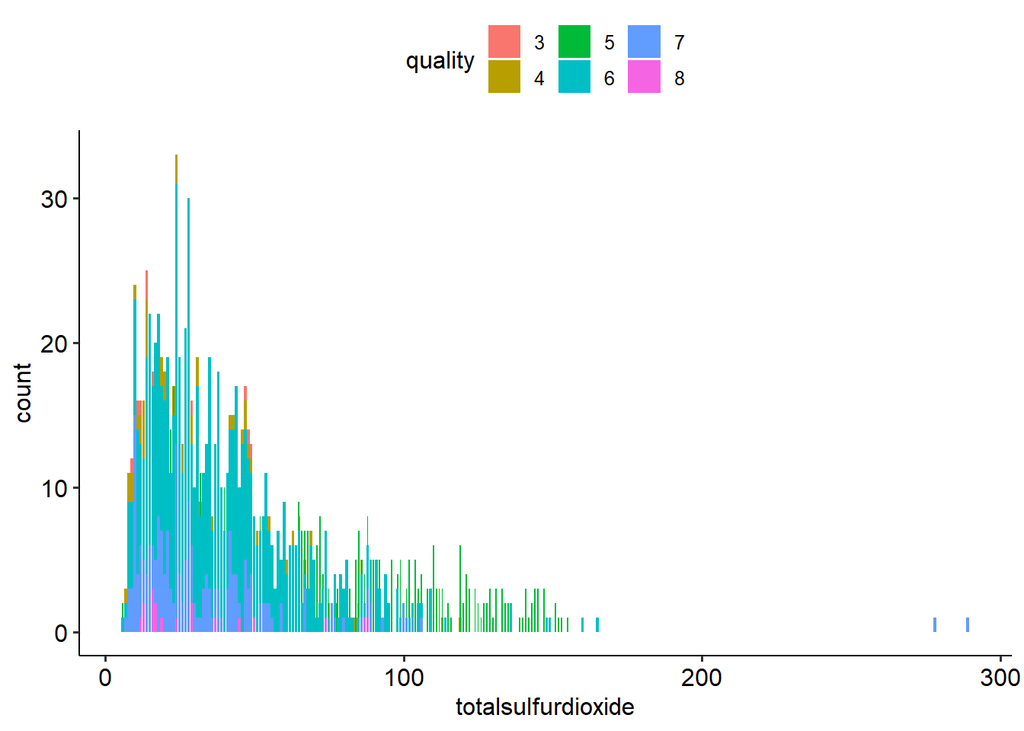

```r
filas=dim(wineQualityRed)[1]

wineQualityRed.f<- wineQualityRed
wineQualityRed.f$quality<- factor(wineQualityRed$quality)

ggplot(data=wineQualityRed.f[1:filas,],aes(x=totalsulfurdioxide,fill=quality))+geom_bar()
```